# Preregistered analysis tested on simulated data

Being made to feel guilty, anticipated pleasantness, moral rightness and donation

Results saved on 03 November 2026, 16:05.

# 1 Why test the analysis on simulated data

**The problem.** In a preregistration, the analysis must be fixed before any data exist. If the code had a mistake, we would only find it after data collection, when changing it could look like adjusting the analysis to the results.

**The solution.** We created one artificial data set with exactly the structure our real data will have: the same groups, the same variables and the same number of participants. We then ran the complete preregistered analysis on it.

**What this shows, and what it does not show.**

- It shows that every model runs, that every effect is converted to Cohen’s *d* correctly, and that each hypothesis receives one of the four planned outcomes.
- It does **not** predict our results. The effects in the artificial data were set by hand to exercise the code. **None of the numbers below are findings.**

# 2 The design

Participants are randomly assigned to four groups, which cross the **guilt induction** (guilt vs. control) with **ratings of the behavioral choice** (rating vs. no rating).

| Groups | Participants | What they do | Hypotheses |
| --- | --- | --- | --- |
| No-rating, guilt and control | 700 each | The procedure of Hurst and Sintov (2022, Study 2) | H2 to H4 |
| Rating, guilt and control | 500 each | The same procedure, plus ratings of how pleasant and how morally right keeping and donating $25 would be, before the raffle description | H5 to H9 |
| All four groups | 2,400 |  | H1 |

# 3 How each hypothesis is tested

| H | Claim | Groups | Model |
| --- | --- | --- | --- |
| H1 | The guilt induction raises experienced guilt | all | linear regression |
| H2 | The guilt induction lowers donation | no-rating | logistic regression |
| H3 | Guiltier people donate more | no-rating | mediation model of Hurst and Sintov, guilt and pride as parallel mediators (PROCESS model 4) |
| H4 | The path through experienced guilt points toward donating | no-rating | same mediation model, indirect effect |
| H5 | Guilt makes keeping more pleasant, relative to donating | rating | linear regression |
| H6 | Guilt makes donating more morally right, relative to keeping | rating | linear regression |
| H7 | Expecting keeping to feel more pleasant goes with keeping | rating | logistic regression with both differences |
| H8 | Judging donating more right goes with donating | rating | same model |
| H9 | Pleasantness is more strongly related to the choice than rightness | rating | same model, sum of the H7 and H8 effects |

All models control for environmental self-identity, gender (woman, man, another gender or not stated), age, political orientation, and education. All effects are expressed as Cohen’s *d*.

# 4 How each result is read

Each hypothesis is decided from the 95% confidence interval of its effect, compared with zero and with the smallest effect size of interest, *d* = 0.20.

| Outcome | Where the 95% CI lies |
| --- | --- |
| Supported | entirely on the predicted side of zero |
| Not supported | entirely below 0.20 in the predicted direction (including the wrong side of zero) |
| Supported but too small to matter | on the predicted side of zero and below 0.20 |
| Inconclusive | it includes both zero and 0.20 |

H9 is read as a comparison only if H7 and H8 point in their predicted directions.

# 5 Results on the simulated data

**Important**

These numbers come from artificial data. They check the code, not the theory.

**What this table shows.** For each hypothesis, the effect as Cohen’s *d*, its 95% confidence interval, and the outcome the decision rules gave.

| H | Claim | N | Prediction | d | 95% CI | Outcome |
| --- | --- | --- | --- | --- | --- | --- |
| H1 | Being made to feel guilty raises experienced guilt | 2400 | + | 1.04 | [0.98, 1.11] | supported |
| H2 | Being made to feel guilty lowers donation | 1400 | - | -0.15 | [-0.27, -0.03] | supported |
| H3 | People who feel guiltier donate more | 1400 | + | 0.16 | [0.09, 0.24] | supported |
| H4 | The part of the effect of the guilt induction that runs through experienced guilt points toward donating | 1400 | + | 0.17 | [0.09, 0.25] | supported |
| H5 | Being made to feel guilty raises the difference in anticipated affect (keeping minus donating) | 1000 | + | 0.36 | [0.24, 0.48] | supported |
| H6 | Being made to feel guilty raises the difference in moral evaluation (donating minus keeping) | 1000 | + | 0.21 | [0.09, 0.33] | supported |
| H7 | A larger difference in anticipated affect goes with less donation | 1000 | - | -0.35 | [-0.43, -0.27] | supported |
| H8 | A larger difference in moral evaluation goes with more donation | 1000 | + | 0.28 | [0.20, 0.36] | supported |
| H9 | The choice is more strongly related to the difference in anticipated affect than to the difference in moral evaluation | 1000 | - | -0.07 | [-0.18, 0.04] | not supported |

**What this figure shows.** Each effect as a dot with its 95% confidence interval.

**How to read it.** The solid line is zero. The dashed lines are the smallest effect size of interest, +0.20 and -0.20. For a hypothesis that predicts an increase, “supported” means the whole interval lies to the right of zero. For one that predicts a decrease (H2, H7, H9), it means the whole interval lies to the left of zero. The colour shows the outcome.

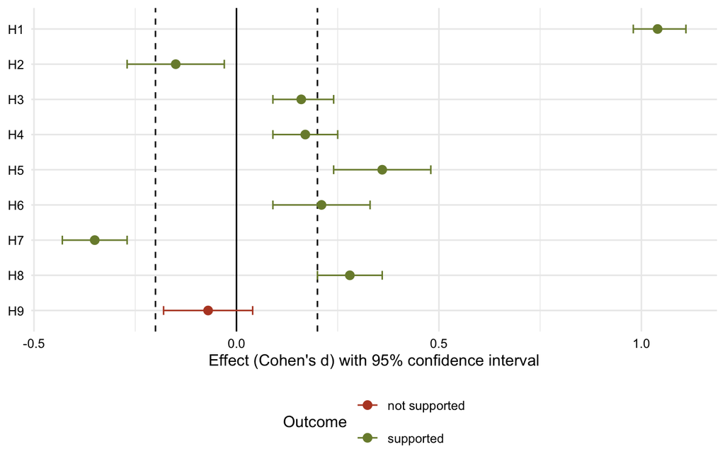

Figure 1

**What this means.** The analysis runs from start to end and applies the decision rules to every hypothesis. Whether a hypothesis comes out supported here depends only on the effects we put into the artificial data.